# Sample Diversity

Chloe J McGovern

2025-04-29

# Goals

Run an analysis on the within-sample biodiversity of the cheese samples.

1. Calculate the Hill Numbers of the samples using the iNEXT package.
2. Plot and evaluate the interpolated and extrapolated rarefaction curves from iNEXT.
3. Test and then answer the scientific question at hand. (But first determine the normality of the data).
1. We will need the `phytree_preprocessed_physeq`, which includes a rooted tree (ideally within the archaea!) that we created in `analysis/04B_Phylogenetic_Tree_Inspection.Rmd`.

## Outputs

1. Calculated biodiversity measures (Hill numbers) across every sample.
2. Figures to include in our scientific paper that visualize the data as it relates to the scientific question.
3. Statistical tests conveying the measured and quantified changes and patterns in biodiversity.

# Scientific Question

## Question & Hypotheses

How is microbial biodiversity changed across different cheese types?

- *Null Hypothesis:* The microbial community does not change with cheese type.
- *Alternative Hypothesis:* Different cheese types have different microbial communities.

# Set up the Environment

## Timing of this script

```r
# What time did we start running this script?
start_time <- Sys.time()
```

## Set the seed

```r
set.seed(238428)
```

## Load Packages & Colors

```r
# install packages for stats
#install.packages("rstatix")
#install.packages("ggpubr")

pacman::p_load(tidyverse, devtools, patchwork, iNEXT, phyloseq,
               # packages for stats
               ggpubr, rstatix, install = FALSE)

# Load in colors for plotting
source("code/colors.R")
```

## Load in Data

```r
load("data/04_PhylogeneticTree/phytree_preprocessed_physeqs.RData")

# take a look at it!
midpoint_rooted_physeq
```

```
## phyloseq-class experiment-level object
## otu_table()   OTU Table:         [ 93 taxa and 20 samples ]
## sample_data() Sample Data:       [ 20 samples by 45 sample variables ]
## tax_table()   Taxonomy Table:    [ 93 taxa by 9 taxonomic ranks ]
## phy_tree()    Phylogenetic Tree: [ 93 tips and 92 internal nodes ]
```

```r
# Intuition check on seq depth
min(sample_sums(midpoint_rooted_physeq))
```

```
## [1] 32004
```

```r
# Make a metadata dataframe
metadata_df <-
  midpoint_rooted_physeq %>%
  sample_data() %>%
  data.frame()

# view of it
glimpse(metadata_df)
```

```
## Rows: 20
## Columns: 45
## $ Assay.Type                     <chr> "AMPLICON", "AMPLICON", "AMPLICON", "AM…
## $ AvgSpotLen                     <dbl> 501, 501, 501, 501, 501, 501, 501, 501,…
## $ Bases                          <dbl> 26751772, 48509001, 44920611, 41740908,…
## $ BioProject                     <chr> "PRJNA555359", "PRJNA555359", "PRJNA555…
## $ BioSample                      <chr> "SAMN12315521", "SAMN12315522", "SAMN12…
## $ BioSampleModel                 <chr> "MIMARKS.specimen", "MIMARKS.specimen",…
## $ Bytes                          <dbl> 19878631, 35989851, 33083974, 30656508,…
## $ Center.Name                    <chr> "UNIVERSIDADE FEDERAL DO RIO GRANDE DO …
## $ cheese_id                      <dbl> 11, 12, 13, 14, 1, 2, 17, 18, 19, 20, 6…
## $ Collection_Date                <date> 2018-04-17, 2018-04-17, 2018-04-17, 20…
## $ Consent                        <chr> "public", "public", "public", "public",…
## $ Cultivar                       <chr> "Not provided", "Not provided", "Not pr…
## $ DATASTORE.filetype             <chr> "fastq,run.zq,sra", "fastq,run.zq,sra",…
```

[output cut: 32 more lines]

```r
# since missing code line for cheese type, hard code a new column called cheese_name
metadata_df <- metadata_df %>%
  mutate(cheese_type = case_when(
    Sample.Name %in% c("Q4", "Q5", "Q6", "Q7", "Q8") ~ "Colonial",
    Sample.Name %in% c("Q1", "Q10", "Q2", "Q3", "Q9") ~ "Feta-type",
    Sample.Name %in% c("Q15", "Q14", "Q13", "Q12", "Q11") ~ "Fresh",
    Sample.Name %in% c("Q16", "Q17", "Q18", "Q19", "Q20") ~ "Pecorino-type"
  ))

# View(metadata_df) YAY it worked!!
```

# Biodiversity Hill Numbers with iNEXT

```r
# prepare the input data
# Species in rows and the samples in columns
iNEXT_input_df <-
  midpoint_rooted_physeq %>%
  otu_table() %>%
  data.frame()

# Inpect
dim(iNEXT_input_df)
```

```
## [1] 93 20
```

```r
iNEXT_input_df[1:5, 1:5]
```

```
##          SRR9722160 SRR9722161 SRR9722162 SRR9722163 SRR9722164
## ASV_0051          0          0          0          0          0
## ASV_0034          0          0          0          0          0
## ASV_0014          0          0          0          0         55
## ASV_0043          0          0          0          0          0
## ASV_0076          0          0          0          0          0
```

```r
# Run iNEXT : Remember to set the seed! It matters a lot for iNEXT -- and it may take some time to run

iNEXT_data <- iNEXT(iNEXT_input_df,
                   q = c(0, 1, 2),
                   datatype = "abundance")

# Inspect
str(iNEXT_data)
```

```
## List of 3
##  $ DataInfo:'data.frame':    20 obs. of  14 variables:
##   ..$ Assemblage: chr [1:20] "SRR9722160" "SRR9722161" "SRR9722162" "SRR9722163" ...
##   ..$ n         : num [1:20] 32004 58676 56254 53609 66632 ...
##   ..$ S.obs     : num [1:20] 9 12 9 14 19 19 10 9 20 20 ...
##   ..$ SC        : num [1:20] 1 1 1 1 1 1 1 1 1 1 ...
##   ..$ f1        : num [1:20] 0 0 0 0 0 0 0 0 0 0 ...
##   ..$ f2        : num [1:20] 0 0 1 0 1 0 0 0 1 0 ...
##   ..$ f3        : num [1:20] 0 0 0 0 0 0 1 0 0 0 ...
##   ..$ f4        : num [1:20] 0 0 0 1 0 1 0 1 0 1 ...
##   ..$ f5        : num [1:20] 0 0 0 0 1 0 0 0 0 0 ...
##   ..$ f6        : num [1:20] 0 0 0 0 1 2 1 0 0 0 ...
##   ..$ f7        : num [1:20] 0 0 1 1 0 0 1 0 0 0 ...
##   ..$ f8        : num [1:20] 0 0 0 1 0 0 0 1 0 1 ...
##   ..$ f9        : num [1:20] 0 0 1 1 0 0 0 0 0 1 ...
##   ..$ f10       : num [1:20] 0 0 0 0 0 1 0 0 0 0 ...
##  $ iNextEst:List of 2
##   ..$ size_based    :'data.frame':   2400 obs. of  10 variables:
##   .. ..$ Assemblage: chr [1:2400] "SRR9722160" "SRR9722160" "SRR9722160" "SRR9722160" ...
##   .. ..$ m         : num [1:2400] 1 1778 3556 5334 7112 ...
##   .. ..$ Method    : chr [1:2400] "Rarefaction" "Rarefaction" "Rarefaction" "Rarefaction" ...
##   .. ..$ Order.q   : num [1:2400] 0 0 0 0 0 0 0 0 0 0 ...
##   .. ..$ qD        : num [1:2400] 1 6.94 8.18 8.68 8.88 ...
##   .. ..$ qD.LCL    : num [1:2400] 1 6.54 7.82 8.44 8.74 ...
##   .. ..$ qD.UCL    : num [1:2400] 1 7.35 8.53 8.91 9.02 ...
##   .. ..$ SC        : num [1:2400] 0.875 0.999 1 1 1 ...
##   .. ..$ SC.LCL    : num [1:2400] 0.87 0.999 1 1 1 ...
##   .. ..$ SC.UCL    : num [1:2400] 0.88 0.999 1 1 1 ...
##   ..$ coverage_based:'data.frame':   1125 obs. of  8 variables:
##   .. ..$ Assemblage: chr [1:1125] "SRR9722160" "SRR9722160" "SRR9722160" "SRR9722160" ...
##   .. ..$ SC        : num [1:1125] 0.875 0.999 1 1 1 ...
##   .. ..$ m         : num [1:1125] 1 1778 3556 5334 7112 ...
##   .. ..$ Method    : chr [1:1125] "Rarefaction" "Rarefaction" "Rarefaction" "Rarefaction" ...
##   .. ..$ Order.q   : num [1:1125] 0 0 0 0 0 0 0 0 0 0 ...
##   .. ..$ qD        : num [1:1125] 1 6.94 8.18 8.68 8.88 ...
##   .. ..$ qD.LCL    : num [1:1125] 0.998 6.464 7.942 8.568 8.829 ...
##   .. ..$ qD.UCL    : num [1:1125] 1 7.42 8.41 8.78 8.93 ...
##  $ AsyEst  :'data.frame':    60 obs. of  7 variables:
##   ..$ Assemblage: chr [1:60] "SRR9722160" "SRR9722160" "SRR9722160" "SRR9722161" ...
##   ..$ Diversity : chr [1:60] "Species richness" "Shannon diversity" "Simpson diversity" "Species richness" ...
##   ..$ Observed  : num [1:60] 9 1.36 1.14 12 1.67 ...
##   ..$ Estimator : num [1:60] 9 1.36 1.14 12 1.67 ...
##   ..$ s.e.      : num [1:60] 0 0.00671 0.00312 0 0.00739 ...
##   ..$ LCL       : num [1:60] 9 1.35 1.14 12 1.66 ...
##   ..$ UCL       : num [1:60] 9 1.37 1.15 12 1.69 ...
##  - attr(*, "class")= chr "iNEXT"
```

```r
typeof(iNEXT_data)
```

```
## [1] "list"
```

# Rarefaction Curves

## `ggiNEXT` Rarefaction Curves

```r
# Prepare Colors
color_df <-
  iNEXT_input_df %>%
  colnames() %>%
  data.frame()
# Check
head(color_df)
```

```
##            .
## 1 SRR9722160
## 2 SRR9722161
## 3 SRR9722162
## 4 SRR9722163
## 5 SRR9722164
## 6 SRR9722165
```

```r
# Rename the column
colnames(color_df)[1] <- "names"
# Check
head(color_df)
```

```
##        names
## 1 SRR9722160
## 2 SRR9722161
## 3 SRR9722162
## 4 SRR9722163
## 5 SRR9722164
## 6 SRR9722165
```

```r
# Make a helper dataframe for plotting with colors
iNEXT_color_df <-
  color_df %>%
  # Merge with metadata
  left_join(metadata_df, by = "names") %>%
  # Merge with colors for plotting with ggiNEXT
  left_join(data.frame(cheese_colors = cheese_colors,
            cheese_type = names(cheese_colors)),
            by = "cheese_type")

head(iNEXT_color_df)
```

```
##        names Assay.Type AvgSpotLen    Bases  BioProject    BioSample
## 1 SRR9722160   AMPLICON        501 26751772 PRJNA555359 SAMN12315521
## 2 SRR9722161   AMPLICON        501 48509001 PRJNA555359 SAMN12315522
## 3 SRR9722162   AMPLICON        501 44920611 PRJNA555359 SAMN12315523
## 4 SRR9722163   AMPLICON        501 41740908 PRJNA555359 SAMN12315524
## 5 SRR9722164   AMPLICON        501 51591656 PRJNA555359 SAMN12315511
## 6 SRR9722165   AMPLICON        501 47588893 PRJNA555359 SAMN12315512
##     BioSampleModel    Bytes                               Center.Name cheese_id
## 1 MIMARKS.specimen 19878631 UNIVERSIDADE FEDERAL DO RIO GRANDE DO SUL        11
## 2 MIMARKS.specimen 35989851 UNIVERSIDADE FEDERAL DO RIO GRANDE DO SUL        12
## 3 MIMARKS.specimen 33083974 UNIVERSIDADE FEDERAL DO RIO GRANDE DO SUL        13
## 4 MIMARKS.specimen 30656508 UNIVERSIDADE FEDERAL DO RIO GRANDE DO SUL        14
## 5 MIMARKS.specimen 38138089 UNIVERSIDADE FEDERAL DO RIO GRANDE DO SUL         1
## 6 MIMARKS.specimen 35327484 UNIVERSIDADE FEDERAL DO RIO GRANDE DO SUL         2
##   Collection_Date Consent     Cultivar DATASTORE.filetype DATASTORE.provider
```

[output cut: 55 more lines]

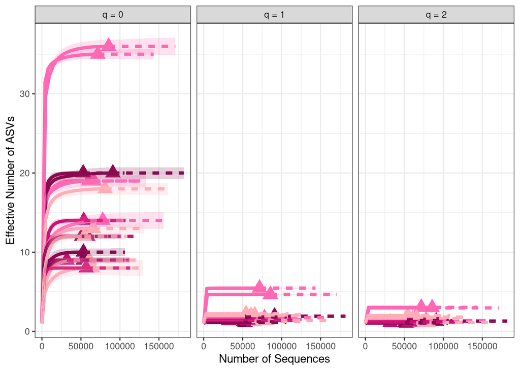

```r
ggiNEXT(iNEXT_data, type = 1, facet.var = "Order.q") +
  scale_color_manual(values = iNEXT_color_df$cheese_colors) +
  scale_fill_manual(values = iNEXT_color_df$cheese_colors) +
  scale_shape_manual(values = base::rep(17, nsamples(midpoint_rooted_physeq))) +
  theme_bw() +
  theme(legend.position = "none") +
  labs(y = "Effective Number of ASVs", x = "Number of Sequences")
```

## Manual Rarefaction Curves

```r
str(iNEXT_data)
```

```
## List of 3
##  $ DataInfo:'data.frame':    20 obs. of  14 variables:
##   ..$ Assemblage: chr [1:20] "SRR9722160" "SRR9722161" "SRR9722162" "SRR9722163" ...
##   ..$ n         : num [1:20] 32004 58676 56254 53609 66632 ...
##   ..$ S.obs     : num [1:20] 9 12 9 14 19 19 10 9 20 20 ...
##   ..$ SC        : num [1:20] 1 1 1 1 1 1 1 1 1 1 ...
##   ..$ f1        : num [1:20] 0 0 0 0 0 0 0 0 0 0 ...
##   ..$ f2        : num [1:20] 0 0 1 0 1 0 0 0 1 0 ...
##   ..$ f3        : num [1:20] 0 0 0 0 0 0 1 0 0 0 ...
##   ..$ f4        : num [1:20] 0 0 0 1 0 1 0 1 0 1 ...
##   ..$ f5        : num [1:20] 0 0 0 0 1 0 0 0 0 0 ...
##   ..$ f6        : num [1:20] 0 0 0 0 1 2 1 0 0 0 ...
##   ..$ f7        : num [1:20] 0 0 1 1 0 0 1 0 0 0 ...
##   ..$ f8        : num [1:20] 0 0 0 1 0 0 0 1 0 1 ...
##   ..$ f9        : num [1:20] 0 0 1 1 0 0 0 0 0 1 ...
##   ..$ f10       : num [1:20] 0 0 0 0 0 1 0 0 0 0 ...
##  $ iNextEst:List of 2
##   ..$ size_based    :'data.frame':   2400 obs. of  10 variables:
##   .. ..$ Assemblage: chr [1:2400] "SRR9722160" "SRR9722160" "SRR9722160" "SRR9722160" ...
##   .. ..$ m         : num [1:2400] 1 1778 3556 5334 7112 ...
##   .. ..$ Method    : chr [1:2400] "Rarefaction" "Rarefaction" "Rarefaction" "Rarefaction" ...
##   .. ..$ Order.q   : num [1:2400] 0 0 0 0 0 0 0 0 0 0 ...
##   .. ..$ qD        : num [1:2400] 1 6.94 8.18 8.68 8.88 ...
##   .. ..$ qD.LCL    : num [1:2400] 1 6.54 7.82 8.44 8.74 ...
##   .. ..$ qD.UCL    : num [1:2400] 1 7.35 8.53 8.91 9.02 ...
##   .. ..$ SC        : num [1:2400] 0.875 0.999 1 1 1 ...
##   .. ..$ SC.LCL    : num [1:2400] 0.87 0.999 1 1 1 ...
##   .. ..$ SC.UCL    : num [1:2400] 0.88 0.999 1 1 1 ...
##   ..$ coverage_based:'data.frame':   1125 obs. of  8 variables:
##   .. ..$ Assemblage: chr [1:1125] "SRR9722160" "SRR9722160" "SRR9722160" "SRR9722160" ...
##   .. ..$ SC        : num [1:1125] 0.875 0.999 1 1 1 ...
##   .. ..$ m         : num [1:1125] 1 1778 3556 5334 7112 ...
##   .. ..$ Method    : chr [1:1125] "Rarefaction" "Rarefaction" "Rarefaction" "Rarefaction" ...
##   .. ..$ Order.q   : num [1:1125] 0 0 0 0 0 0 0 0 0 0 ...
##   .. ..$ qD        : num [1:1125] 1 6.94 8.18 8.68 8.88 ...
##   .. ..$ qD.LCL    : num [1:1125] 0.998 6.464 7.942 8.568 8.829 ...
##   .. ..$ qD.UCL    : num [1:1125] 1 7.42 8.41 8.78 8.93 ...
##  $ AsyEst  :'data.frame':    60 obs. of  7 variables:
##   ..$ Assemblage: chr [1:60] "SRR9722160" "SRR9722160" "SRR9722160" "SRR9722161" ...
##   ..$ Diversity : chr [1:60] "Species richness" "Shannon diversity" "Simpson diversity" "Species richness" ...
##   ..$ Observed  : num [1:60] 9 1.36 1.14 12 1.67 ...
##   ..$ Estimator : num [1:60] 9 1.36 1.14 12 1.67 ...
##   ..$ s.e.      : num [1:60] 0 0.00671 0.00312 0 0.00739 ...
##   ..$ LCL       : num [1:60] 9 1.35 1.14 12 1.66 ...
##   ..$ UCL       : num [1:60] 9 1.37 1.15 12 1.69 ...
##  - attr(*, "class")= chr "iNEXT"
```

```r
iNEXT_manual_df <-
  iNEXT_data$iNextEst$size_based %>%
  dplyr::rename(names = Assemblage) %>%
  # fix the samples to merge with metadata
  mutate(names = gsub(names, pattern = "[.]", replace = "-"),
         names = gsub(names, pattern = "X", replace = "")) %>%
  # join with the metadata
  left_join(., metadata_df, by = "names") %>%
  mutate(cheese_type = factor(cheese_type, levels = c("Colonial",
                                              "Feta-type",
                                              "Fresh",
                                              "Pecorino-type")))

# Inspection
dim(iNEXT_manual_df)
```

```
## [1] 2400   55
```

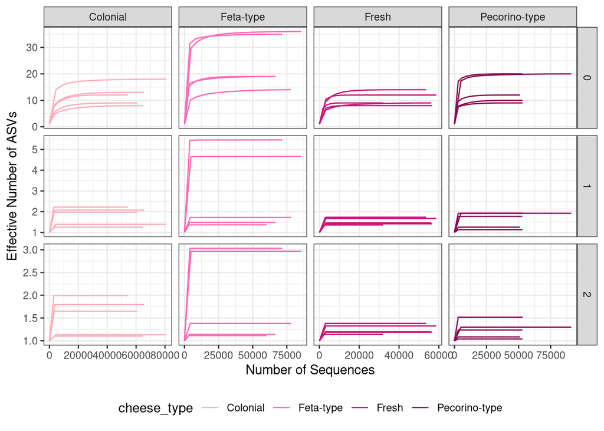

```r
# Manually plot rarefaction curves
iNEXT_manual_df %>%
  dplyr::filter(Method == "Rarefaction") %>%
  ggplot(aes(x = m, y = qD, color = cheese_type, group = names)) +
  geom_line() +
  facet_grid(Order.q~cheese_type, scales = "free") +
  scale_color_manual(values = cheese_colors) +
  theme_bw() +
  labs(y = "Effective Number of ASVs", x = "Number of Sequences") +
  theme(legend.position = "bottom")
```

[output not shown]

# Statististical Testing

Understanding the difference between parametric and non-parametric statistics is essential for choosing the right test for your data, especially in microbial ecology where data often violate assumptions of normality.

In order to know if I need to use parametric or non-parametric tests, first I need to test for the normality of the data. However, Shapiro-Wilk’s test is only good for continuous data; this may be better suited for more well rounded cheese metadata with factors like pH, aging, moisture content. My metadata is only categorical for cheese type so the statistics will be limited.

I should be able to test if the richness values are normal so let’s do that here so I know if I can use parametric or non-parametric methods for categorical data statistics.

### Shaprio-Wilk

```r
### Now what about for richness?
obs_div_df <-
  iNEXT_manual_df %>%
  dplyr::filter(Method == "Observed")

# check it
glimpse(obs_div_df)
```

```
## Rows: 60
## Columns: 55
## $ names                          <chr> "SRR9722160", "SRR9722160", "SRR9722160…
## $ m                              <dbl> 32004, 32004, 32004, 58676, 58676, 5867…
## $ Method                         <chr> "Observed", "Observed", "Observed", "Ob…
## $ Order.q                        <dbl> 0, 1, 2, 0, 1, 2, 0, 1, 2, 0, 1, 2, 0, …
## $ qD                             <dbl> 9.000000, 1.361223, 1.143031, 12.000000…
## $ qD.LCL                         <dbl> 9.000000, 1.345138, 1.136097, 12.000000…
## $ qD.UCL                         <dbl> 9.000000, 1.377307, 1.149965, 12.000000…
## $ SC                             <dbl> 1, 1, 1, 1, 1, 1, 1, 1, 1, 1, 1, 1, 1, …
## $ SC.LCL                         <dbl> 1.0000000, 1.0000000, 1.0000000, 1.0000…
## $ SC.UCL                         <dbl> 1, 1, 1, 1, 1, 1, 1, 1, 1, 1, 1, 1, 1, …
## $ Assay.Type                     <chr> "AMPLICON", "AMPLICON", "AMPLICON", "AM…
## $ AvgSpotLen                     <dbl> 501, 501, 501, 501, 501, 501, 501, 501,…
## $ Bases                          <dbl> 26751772, 26751772, 26751772, 48509001,…
```

[output cut: 42 more lines]

```r
# Pull out unique data from the three fractions of samples
obs_whole_rich_df <-
  obs_div_df %>%
  dplyr::filter(Order.q == 0)

# Test of the data is normal for the continuous value of richness
shapiro.test(obs_whole_rich_df$qD)
```

```
##
##  Shapiro-Wilk normality test
##
## data:  obs_whole_rich_df$qD
## W = 0.78725, p-value = 0.000561
```

The data is not normal. I will have to use non-parametric statistics.

# Categorical Analysis by Cheese Type

### Diversity by Cheese Type

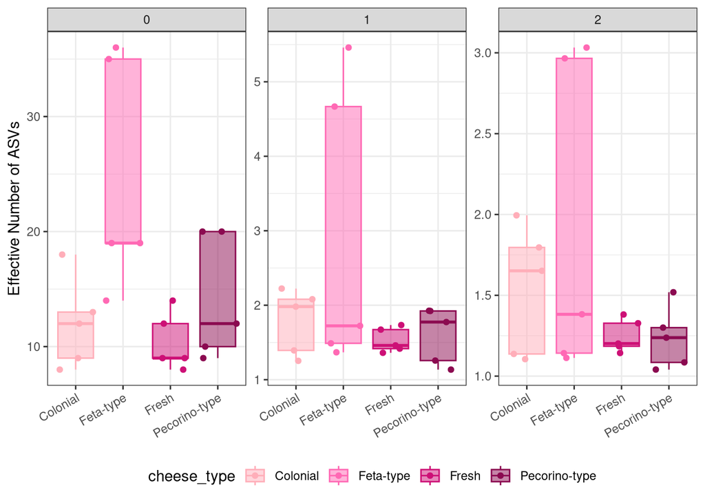

```r
# Plot boxplots by cheese type against diversity
obs_div_df %>%
  ggplot(aes(x = cheese_type, y = qD, fill = cheese_type,
             color = cheese_type)) +
  facet_wrap(.~Order.q, scales = "free_y") +
  geom_jitter() +
  geom_boxplot(alpha = 0.5, outlier.shape = NA) +
  scale_color_manual(values = cheese_colors) +
  scale_fill_manual(values = cheese_colors) +
  labs(y = "Effective Number of ASVs") +
  theme_bw() +
  theme(legend.position = "bottom",
        axis.title.x = element_blank(),
        axis.text.x = element_text(angle = 30,
                                   hjust = 1,
                                   vjust = 1))
```

#### Statistically test Richness

```r
# Pull out richness data
obs_rich_df <-
  obs_div_df %>%
  dplyr::filter(Order.q == 0)

# Run Kruskal-Wallis test
kruskal_cheese_rich <- kruskal.test(qD ~ cheese_type, data = obs_rich_df)

# Look at it
kruskal_cheese_rich
```

```
##
##  Kruskal-Wallis rank sum test
##
## data:  qD by cheese_type
## Kruskal-Wallis chi-squared = 8.605, df = 3, p-value = 0.03503
```

```r
# Richness by cheese type (Kruskal + Dunn)
rich_ggboxplot <-
  ggboxplot(obs_rich_df, x = "cheese_type", y = "qD",
          color = "cheese_type", fill = "cheese_type", alpha = 0.3,
          outlier.shape = NA) +
  geom_jitter(aes(color = cheese_type)) +
  scale_color_manual(values = cheese_colors) +
  scale_fill_manual(values = cheese_colors) +
  labs(y = "# of Total ASVs (Richness)") +
  # Add Kruskal-Wallis test
  stat_compare_means(method = "kruskal.test", label.y = min(obs_rich_df$qD)) +
  # Add Dunn test comparisons
  geom_pwc(
    aes(group = cheese_type), tip.length = 0, hide.ns = TRUE,
    method = "dunn_test", label = "p.adj.format",
    p.adjust.method = "fdr", bracket.nudge.y = -0.08) +
  theme_bw() +
  theme(legend.position = "none",
        axis.title.x = element_blank(),
        axis.text.x = element_text(angle = 30,
                                   hjust = 1,
                                   vjust = 1))
```

### Simpson

```r
# Pull out simpson data
obs_simps_df <-
  obs_div_df %>%
  dplyr::filter(Order.q == 2)

# Run Kruskal-Wallis test
kruskal_cheese_simps <- kruskal.test(qD ~ cheese_type, data = obs_simps_df)

# Look at it
kruskal_cheese_simps
```

```
##
##  Kruskal-Wallis rank sum test
##
## data:  qD by cheese_type
## Kruskal-Wallis chi-squared = 1.9829, df = 3, p-value = 0.576
```

```r
# Simpson by cheese type (Kruskal + Dunn)
simps_ggboxplot <-
  ggboxplot(obs_simps_df, x = "cheese_type", y = "qD",
          color = "cheese_type", fill = "cheese_type", alpha = 0.3,
          outlier.shape = NA) +
  geom_jitter(aes(color = cheese_type)) +
  scale_color_manual(values = cheese_colors) +
  scale_fill_manual(values = cheese_colors) +
  labs(y = "# of Dominant ASVs (Simpson)") +
  stat_compare_means(method = "kruskal.test", label.y = max(obs_simps_df$qD) * 1.02) +
  geom_pwc(
    aes(group = cheese_type), tip.length = 0, hide.ns = TRUE,
    method = "dunn_test", label = "p.adj.signif",
    step.increase = 0.08,
    p.adjust.method = "fdr", bracket.nudge.y = -0.08) +
  theme_bw() +
  theme(legend.position = "none",
        axis.title.x = element_blank(),
        axis.text.x = element_text(angle = 30,
                                   hjust = 1,
                                   vjust = 1))
```

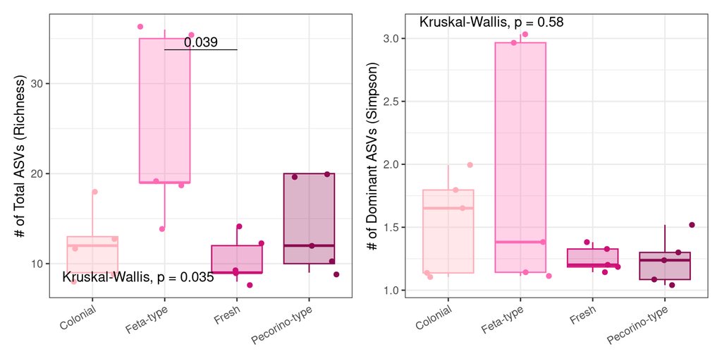

```r
# Show the plots
rich_ggboxplot + simps_ggboxplot
```

Interpretation 2: Looking at richness, feta-type cheeses harbor more total bacterial taxa (including both rare and common ASVs), whereas the others have fewer total ASVs. This points to higher overall microbial richness in Feta-type cheese. Despite big differences in total richness, all cheese types have a similar core of dominant bacterial species. In other words, no matter the cheese type, one or two ASVs tend to dominate—an expected trend of fermented dairy.

Since my data is categorical, I will not run further analyses.

# Final info for Reproducibility

## Check Render Time

```r
# Take the time now that we are at the end of the script
end_time <- Sys.time()
end_time
```

```
## [1] "2025-04-29 11:37:08 EDT"
```

```r
# Echo the elapsed time
elapsed_time <- round((end_time - start_time), 3)
elapsed_time
```

```
## Time difference of 5.72 mins
```